# Homework 2-Titis in the Mist

Angelique J. Lindberg

2023-10-01

Every Saturday morning, at the same time, a primatologist goes and sits in the forest to listen for titi monkey calls, counting the number of calls they hear in a 2 hour window from 5am to 7am. Based on previous knowledge, she believes that the mean number of calls she will hear in that time is exactly 15. Let X represent the appropriate Poisson random variable of the number of calls heard in each monitoring session.

## What is the probability that she will hear more than 8 calls during any given session?

```r
X=8
1-ppois(q=X, lambda=15)
```

```
## [1] 0.9625535
```

## What is the probability that she will hear no calls in a session?

```r
X=0
dpois(X, lambda = 15)
```

```
## [1] 3.059023e-07
```

## What is the probability that she will hear exactly 3 calls in a session?

```r
X<-3
dpois(X, lambda=15)
```

```
## [1] 0.0001720701
```

## Plot the relevant Poisson mass function over the values in range 0 ≤ x ≤ 30.

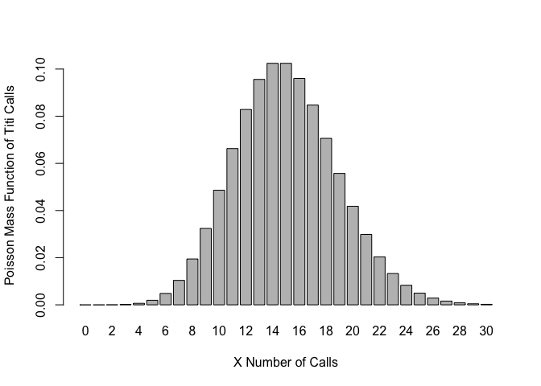

```r
pmf<-barplot(dpois(0:30, lambda = 15), names.arg = 0:30, ylab = "Poisson Mass Function of Titi Calls", xlab = "X Number of Calls")
```

## Simulate 104 results from this distribution (i.e., 2 years of Saturday monitoring sessions).

```r
twoyr<-rpois(104, lambda = 15)
twoyr
```

```
##   [1] 10 12 12 13 17 10 24 16 14 15 18  9 14 13 13 17 16 21 17 12 16 14 22 11 13
##  [26] 13 15 20 21 12 20 14 16 12 20 24 17 12 15 13 13 14  8 15 14 17 16 10 15 15
##  [51] 17 14  9 16 12 10 20 21 19 10 15 18 14 14  8 18 17 13 19 12 10 13 13 16 25
##  [76] 10 14 21 13  7 17 14 16 10 24 13 12 18 11 19 19 11 17 17 16 17 14 11 19 10
## [101]  7 13 15 19
```

## Plot the simulated results using hist() and use xlim() to set the horizontal limits to be from 0 to 30.

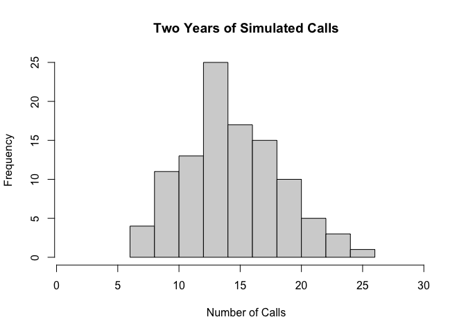

```r
htwoyr<-hist(twoyr, xlim = c(1,30), xlab = "Number of Calls", main = "Two Years of Simulated Calls")
```

## How does your histogram compare to the shape of the probability mass function you plotted above?

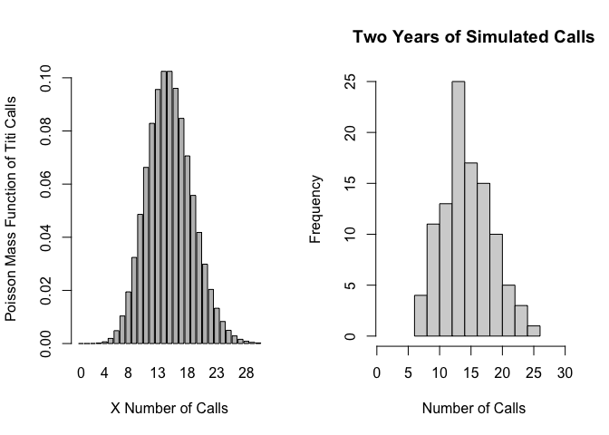

```r
par(mfrow= c(1,2))
barplot(dpois(0:30, lambda = 15), names.arg = 0:30, ylab = "Poisson Mass Function of Titi Calls", xlab = "X Number of Calls")
hist(twoyr, xlim = c(1,30), xlab = "Number of Calls", main = "Two Years of Simulated Calls")
```

## Challenges

1. Combining the techniques I learned from multiple different modules was a little tricky because of the nitpicky differences in syntax details. I vaguely know how to do something and remember learning it but finding the exact context of it in order to track down the right code to copy was tricky. On the plus side, I’m getting better at googling errors and finding quick answers instead of hunting through my notes.
2. It took me forever to figure out probability mass functions and their relations to distributions for some reason. I think I just went through it too fast the first time and got confused so I spent several hours this weekend going back through, taking better notes, just thinking things through, and that helped.
3. For little issues I ran into, like remembering when I want to use dpois vs ppois vs rpois, I relied pretty heavily on the Book of R chapter 16.